# Websites in RStudio

Dani Cosme & Sam Chavez

06-03-2018

### Overview of the tutorial

1. Background
2. Learn the basics
3. Explore advanced features
4. Check out the `hugo-academic` theme
5. Publish your website to GitHub

# Background

Most of the information in this tutorial is taken from a few amazing resources on using the **blogdown** package to create static websites in RStudio using R Markdown:

- [*blogdown: Creating Websites with R Markdown*](https://bookdown.org/yihui/blogdown/)
- Various presentations and posts by Alison Hill
  - https://apreshill.github.io/data-vis-labs-2018/slides/06-slides_blogdown.html#1
  - https://alison.rbind.io/slides/blogdown-workshop-slides
  - https://alison.rbind.io/post/up-and-running-with-blogdown/#build-your-site-in-rstudio

## Why use RStudio to make static websites?

- It’s easy
- It’s free
- It’s a simple way to share your code and analyses

## What is blogdown?

**blogdown** is a package that leverages R Markdown and Hugo to create static websites.

## What is Hugo?

Hugo is a static website generator. Static websites are collections of HTML files and the external dependencies referenced within them. More on Hugo [here](https://bookdown.org/yihui/blogdown/hugo.html).

# Learn the basics

## Install blogdown and hugo

```r
if (!require(blogdown)) {
  install.packages("blogdown")
}
blogdown::install_hugo()
```

## Update hugo if necessary

```r
blogdown::hugo_version()
blogdown::update_hugo()
```

## Create a website using the default lithium template

There are a number of ways to create a new website project. You can create it using the IDE by clicking `File > New Project > New Directory > Website Using Blogdown` or by simply specifying the path to the new website as a argument in the `blogdown::new_site()` function. Make sure that you specify the new directory (e.g. the name of the folder you would like to create) in the path.

Here we’ll create the website one level above our current working directory. The reason for doing this is that our current working directory is a git repository and if we try to publish this later, it will cause problems (it’s not straight forward to have a repo inside of a repo).

```r
blogdown::new_site("../default-site")
```

You can also specify a theme when creating your new site. The default is the [lithium theme](https://github.com/yihui/hugo-lithium), but there are a variety of other [Hugo themes](https://themes.gohugo.io/) available. We’ll use the hugo-academic theme later in the tutorial.

```
blogdown::new_site(theme = 'yihui/hugo-lithium')
blogdown::new_site(theme = 'devcows/hugo-universal-theme')
blogdown::new_site(theme = 'gcushen/hugo-academic')
```

## Render the site

Anytime you want to render the site, you can do so by either clicking `Addins > Serve Site` or executing the `blogdown::serve_site()` function. This function should be executed from the site directory, so if you are not currently in that directory, make sure to change you current working directory to the site directory.

```r
setwd("../default-site/")
blogdown::serve_site()
```

## Where does the content live?

Take a look at what’s in the site directory.

Key components:  
* `config.toml` = configuration file that the user edits to customize their site  
* `/content/` = where the actual content (e.g. pages, posts live)  
* `/public/` = the directory containing the website for online deployment  
* `/layouts/` = where you’ll place code to override the original template design  
* `/static/` = where content such as images and CSS code are stored  
* `/theme/` = where the theme template is stored

## `config.toml` file

The configuration file is where global variables and settings are defined. More about configuration files and the variables specified within it [here](http://gohugo.io/getting-started/configuration/). More information on TOML syntax [here](https://bookdown.org/yihui/blogdown/configuration.html#toml-syntax).

### Edit `config.toml`

Change the site name

```
title = "Dani Cosme, M.S."
```

Enable emojis

```
enableEmoji = true
```

### Navigation bar

More on menu management [here](https://gohugo.io/variables/menus/). `[[menu.main]]` = Pages and links in the menu bar

- Can be external links (e.g. Twitter page) or internal links (e.g. /posts/)
- Default arrangement is alphabetical order
- To manually specify the order, add `weight` as a field

Add the following text to your `config.toml` page and see what happens:

```
[[menu.main]]
    name = "UO Data Science Club"
    url = "https://github.com/uodatascience"
    weight = 1
```

## Homepage

Create a file called `index.html` in the `layouts/` directory.

```bash
touch ../default-site/layouts/index.html
```

Copy the following text into `layouts/index.html`. I borrowed this code from [Alison Hill’s awesome blogdown tutorial](https://github.com/rladies-pdx/rladies-PDX/blob/master/layouts/index.html), but you could write your own html code to create the layout for your homepage.

```
{{ partial "header" . }}

<div class="intro">
        <div><center><img class="center-image" src={{ .Site.Params.img }} width="20%"/></center></div>

        <h1><center>{{ markdownify .Title }}</center></h1>

        <h2><center>{{ markdownify .Site.Params.Description }}</center></h2>

</div>


{{ partial "footer" . }}
```

We referenced a field`.Site.Params.img`, but it currently doesn’t exist. Let’s add it to `config.toml` and also update the site description.

```
[params]
    description = "Welcome to my website!<br>Here is a bunch of text about me.<br>Yada yada yada."
    img = "https://avatars1.githubusercontent.com/u/11858670?s=460&v=4"
```

Since the posts are no longer on linked from the landing page, let’s add the `Posts` page to the navigation bar by adding it as a field in `config.toml`:

```
[[menu.main]]
    name = "Posts"
    url = "/post/"
```

## About page

Open `/content/about.md` and check it out. Add the following text to the `about.md` file and look at the difference.

[output not shown]

## Pages

Create a new page called `CV` in the content folder.

```r
setwd("../default-site/")
blogdown::new_content("content/cv")
```

Copy the following text into the document:

```
---
title: ''
date: '2018-06-03 23:25:08 GMT'
---

<div style="text-align: right"><h1>DANI COSME</div>
<div style="text-align: right">dcosme@uoregon.edu</div>
<div style="text-align: right"><a href="http://dcosme.github.io">dcosme.github.io</a></div>

### EDUCATION //
**Doctoral Candidate, Psychology, 2015-present**<br>
University of Oregon (Eugene, OR)<br>
Advisors: Drs. Jennifer Pfeifer & Elliot Berkman

### PUBLICATIONS //
**Cosme, D.** (2018) Brilliant article. *Science*, 1(1), 1-5.<br>
[DOI](http://doi.org/) [OSF](http://osf.io/) [NEUROVAULT](http://neurovault.org/)
```

Add the page to the navigation bar by adding the following text to `config.toml`. Note that while the filepath is `site root/content/cv.md`, the webpath is `/baseurl/cv`.

```
[[menu.main]]
    name = "CV"
    url = "/cv/"
```

This is the start of a super basic markdown CV, but there are a number of more advanced templates out there, such as [this one](https://github.com/elipapa/markdown-cv).

## Posts

Open `content/post` and look around.

### Create a new post

Using the IDE: `Addins > New Post`

In the console, the `new_post()` function will automatically create a new post and append the date to the front of the file name that you specify as an input.

#### Markdown post

Let’s create a plain markdown post and add some content.

```r
setwd("../default-site/")
blogdown::new_post("newmd", ext = '.md')
```

Add the following text to the new `.md` file:

```
Here is some text. Lots of text. So much text.

**Gee this is fun!**

Let's add a table, just for kicks.

| hours of sun | happiness |
|---|---|
| 0 | 1 |
| 3 | 4 |
| 5 | 7 |
| 7 | 10 |
```

Add the following r code chunks (removing `eval=FALSE`) and view the file in the browser:

```r
mean(iris$Sepal.Length)
```

```r
require(ggplot2)
ggplot(iris, aes(Sepal.Length, Sepal.Width, color = Species)) +
  geom_point() +
  geom_smooth(method = "lm") +
  scale_color_manual(values = c("#3B9AB2", "#E4B80E", "#F21A00"))
```

#### Rmarkdown post

```r
setwd("../default-site/")
blogdown::new_post("newrmd", ext = '.Rmd')
```

Add the same text as above to your `.Rmd` file and view it in the browser. We can see that the text looks similar in both files, but only in the R Markdown file are we able to execute code chunks.

This feature makes R Mardown posts ideal for sharing code via your website.

#### Adding HTML files directly

Rather than creating a markdown post, you may simply want to an HTML file that you’ve already created (e.g. your data science tutorial). To do this, you would simply copy the file into `/content/` or an alternative location.

To compare the output of adding an HTML file versus adding an Rmd file, we’ll create a folder called “data-visualization” and copy two test files into it.

```bash
# make the directory
mkdir ../default-site/content/data-visualization

# copy the HTML and .Rmd files to the directory
cp datavis.html ../default-site/content/data-visualization
cp datavis_rmd.Rmd ../default-site/content/data-visualization
```

Serve the site

```r
setwd("../default-site/")
blogdown::serve_site()
```

Compare the files by opening the site in the browser and navigating to:

```
/data-visualization/datavis
/data-visualization/datavis_rmd
```

# Advanced features

## Password protection

Here’s a script to enable password protection on a portion of your website.

```html
<SCRIPT>
function passWord() {
var testV = 1;
var pass1 = prompt('Please Enter Your Password',' ');
while (testV < 3) {
if (!pass1)
history.go(-1);
if (pass1.toLowerCase() == "my super secret password") {
window.open('EasterEgg.html');
break;
}
testV+=1;
var pass1 =
prompt('Access Denied - Password Incorrect, Please Try Again.','Password');
}
if (pass1.toLowerCase()!="password" & testV ==3)
history.go(-1);
return " ";
}
</SCRIPT>
<CENTER>
<FORM>
<input type="button" value="Enter Protected Area" onClick="passWord()">
</FORM>
</CENTER>
```

## Shiny apps

### The Structure of a Shiny App

Shiny apps are contained in a single, integrated script called app.R.

This script has at least three components:

- a user interface object (can be a call to a separate ui.R script)
- a server function (can be a call to a separate server.R script)
- a call to the shinyApp function
- optional: extra stuff in your global environment (can be a call to a separate global.R script)
- If you want to host your shiny app, save this script as app.R and put it in it’s own folder. The name for that folder will be the name of your shiny app.

```r
# If you choose to host this app online, you'll need to copy everything in this code chunk and save it to app.R in it's own folder.  Then, set your working directory to the saved folder.  Finally, use the command 'rsconnect::deployApp()' to host your app.

# Here's a user interface (ui) component
library(shiny)

# Define UI for app that draws a histogram ----
ui <- fluidPage(

  # App title ----
  titlePanel("Hello Shiny!"),

  # Sidebar layout with input and output definitions ----
  sidebarLayout(

    # Sidebar panel for inputs ----
    sidebarPanel(

      # Input: Slider for the number of bins ----
      sliderInput(inputId = "bins",
                  label = "Number of bins:",
                  min = 1,
                  max = 50,
                  value = 30)

    ),

    # Main panel for displaying outputs ----
    mainPanel(

      # Output: Histogram ----
      plotOutput(outputId = "distPlot")

    )
  )
)

# Here's a server component

# Define server logic required to draw a histogram ----
server <- function(input, output) {

  # Histogram of the Old Faithful Geyser Data ----
  # with requested number of bins
  # This expression that generates a histogram is wrapped in a call
  # to renderPlot to indicate that:
  #
  # 1. It is "reactive" and therefore should be automatically
  #    re-executed when inputs (input$bins) change
  # 2. Its output type is a plot
  output$distPlot <- renderPlot({

    x    <- faithful$waiting
    bins <- seq(min(x), max(x), length.out = input$bins + 1)

    hist(x, breaks = bins, col = "#75AADB", border = "white",
         xlab = "Waiting time to next eruption (in mins)",
         main = "Histogram of waiting times")

    })

}

# When you've made both components, you're ready to call shinyApp

shinyApp(ui = ui, server = server)
```

### Layout

The layout of a shiny app is specified within the user interface with the function fluidPage() using the panel options.

- Specify a title with titlePanel(“my title”)
- Parition your layout into sidebar & main panels
- Change the position of a panel
- You can use some HTML5 tags without the <> brackets too
- Use ‘align’ to change text justification
- Use p() to create paragraphs

And so much more…

```r
ui <- fluidPage(
  titlePanel(em("my italicized title", align = "center")),

  sidebarLayout(position = "left",
                sidebarPanel(strong("my bold sidebar\nand a picture\nof a shiny penny"),
                             img(src = "https://www.thefarmersbank.net/wp-content/uploads/2018/04/2005-Penny-Uncirculated-Obverse.png", height = 100, width = 100)),
                mainPanel(
                  h1("most important output"),
                  br(),
                  p("this is a paragraph that says nothing in particular.  it's just a bunch of sentences to illustrate a point about separating text.  watch, we're going to copy and paste it below as another paragraph."),
                  p("this is a paragraph that says nothing in particular.  it's just a bunch of sentences to illustrate a point about separating text."),
                  h2("less important output"),
                  h3(div("here's smaller text in blue", style = "color:blue")),
                  h4(p("here's a tiny text paragraph with just", span("a few orange words,", style = "color:orange"), "if you're into that."))
                )
  )
)

# Let's see what we created
# Uncomment the lines below and run this chunk only

server <- function(input, output) {
}
shinyApp(ui, server)
```

[interactive chart not shown]

### Control Widgets

Widgets are the interactive parts of a web application. When we include widgets in our shiny app, the user can manipulate features of the UI. Later, we’ll learn how to make the output of our app reflect these changes dynamically.

- Shiny has some built-in widgets. Below, we’ve listed their names and corresponding functions.

| Function | Widget |
| --- | --- |
| actionButton | Action Button |
| checkboxGroupInput | A group of check boxes |
| checkboxInput | A single check box |
| dateInput | A calendar to aid date selection |
| dateRangeInput | A pair of calendars for selecting a date range |
| fileInput | A file upload control wizard |
| helpText | Help text that can be added to an input form |
| numericInput | A field to enter numbers |
| radioButtons | A set of radio buttons |
| selectInput | A box with choices to select from |
| sliderInput | A slider bar |
| submitButton | A submit button |
| textInput | A field to enter text |

Note: If that’s not enough for you, install the shinyWidgets package for more!

- To add control widgets to your app, put one of the widget functions in the sidebarPanel or mainPanel of your UI. Every widget needs these ingredients:
  - a name (charcter string that you call later)
  - label (character string that the app user will see)

```r
#install.packages("shinyWidgets")
library(shinyWidgets)

library(shiny)

# Define UI ----
ui <- fluidPage(
  titlePanel("A Bunch of Widgets"),

  fluidRow(

    column(3,
           h3("Button Widgets"),
           actionButton("action", "Action"),
           br(),
           br(),
           br(),
           submitButton("Submit"),
           br(),
           br(),
           br(),
           actionBttn("fancy action", "Danger! Don't Click Me",
                      style = "jelly", color = "danger", size = "lg"),
           br(),
           br(),
           br(),
           actionGroupButtons(
             inputIds = c("btn1", "btn2", "btn3"),
             labels = list("Action 1", "Action 2", tags$span(icon("gear"), "Action 3")),
             status = "primary"),
           br(),
           br(),
           br(),
           downloadBttn("download button", "Click to Download"),
           br(),
           br(),
           br(),
           prettyRadioButtons(inputId = "radio4", label = "Click me!",
                              choices = c("Click me !", "Me !", "Or me !"),
                              outline = TRUE,
                              plain = TRUE, icon = icon("thumbs-up"))),

    column(3,
           h3("Checkbox Widgets"),
           checkboxInput("checkbox", "Choice A", value = TRUE),
           br(),
           br(),
           checkboxGroupInput("checkGroup", "Checkbox group",
           choices = list("Choice 1" = 1,
                          "Choice 2" = 2,
                          "Choice 3" = 3), selected = 1),
           br(),
           br(),
           prettyCheckbox(inputId = "checkbox2",
                          label = "Click me!", thick = TRUE,
                          animation = "pulse", status = "info",
                          fill = T, shape = "round", bigger = T),
           br(),
           br(),
           prettyCheckboxGroup(inputId = "checkgroup5",
                               label = "Click me!", icon = icon("check"),
                               choices = c("Click me !", "Me !", "Or me !"),
                               animation = "rotate", status = "default"),
           br(),
           br(),
           h4("pretty sweet checkbox"),
           prettyToggle(inputId = "toggle4",
                        label_on = "Yes!",
                        label_off = "No..", outline = TRUE,
                        plain = TRUE, icon_on = icon("thumbs-up"),
                        icon_off = icon("thumbs-down"))),

    column(3,
           h3("Date/Calendar Widgets"),
           airDatepickerInput(inputId = "default",
                              label = "Choose a date:"),
           br(),
           airDatepickerInput(inputId = "range",
                              label = "Select range of dates:",
                              range = TRUE, value = c(Sys.Date()-7, Sys.Date())),
           br(),
           airDatepickerInput(inputId = "multiple times",
                              label = "Indicate 3 times you're free to meet:",
                              timepicker = T,
                              placeholder = "meeting times",
                              multiple = 3, separator = " ; ",
                              clearButton = TRUE),
           airDatepickerInput(inputId = "inline",
                              label = "Inline:",
                              inline = TRUE))
  ),

  fluidRow(

    column(3,
           fileInput("file", h3("File input"))),

    column(3,
           h3("Help text"),
           helpText("Note: help text isn't a true widget,",
                    "but it provides an easy way to add text to",
                    "accompany other widgets.")),

    column(3,
           numericInput("num",
                        h3("Numeric input"),
                        value = 1))
  ),

  fluidRow(

    column(3,
           radioButtons("radio", h3("Radio buttons"),
                        choices = list("Choice 1" = 1, "Choice 2" = 2,
                                       "Choice 3" = 3),selected = 1)),

    column(3,
           selectInput("select", h3("Select box"),
                       choices = list("Choice 1" = 1, "Choice 2" = 2,
                                      "Choice 3" = 3), selected = 1)),

    column(3,
           sliderInput("slider1", h3("Sliders"),
                       min = 0, max = 100, value = 50),
           sliderInput("slider2", "",
                       min = 0, max = 100, value = c(25, 75))
    ),

    column(3,
           textInput("text", h3("Text input"),
                     value = "Enter text..."))
  )

)

# Define server logic ----
server <- function(input, output) {

}

# Run the app ----
shinyApp(ui = ui, server = server)
```

[interactive chart not shown]

### Displaying Reactive Output

Reactive output displays automatically when a user interacts with your shiny app using one (or more) of the control widgets we just made.

We can make reactive output in two steps:

1. Add an R object in your UI function. Shiny has built-in functions to turn your R objects into UI-compatible output. Here’s a table with those built-in output functions and what they do.

| Output Function | Object It Makes |
| --- | --- |
| dataTableOutput | DataTable |
| htmlOutput | raw HTML |
| imageOutput | image |
| plotOutput | plot |
| tableOutput | table |
| textOutput | text |
| uiOutput | raw HTML |
| verbatimTextOutput | text |

- Put your output function in the your UI, in either the sidebarPanel or mainPanel.
- Your output function will take a character string, in quotes, as an argument. This character string corresponds to the name of a control widget in your UI.

```r
# Here's an example based on one of the widgets we made earlier.

ui <- fluidPage(
  titlePanel("The Presidential Launch Codes"),

  sidebarLayout(
    sidebarPanel(
      helpText("Be careful.  Interacting with this shiny app could cause the world to implode."),

      actionBttn("fancy_action", "Danger! Don't Click Me",
                      style = "jelly", color = "danger", size = "lg")
    ),

    mainPanel(
      imageOutput("res_fancy_action")
    )
  )
)
```

2. Tell R how to build the object in your server function
- The server function makes on object called ‘output’ that contains a list of all the things we need to make a shiny app.
- Each output object that you make from step 1 needs to have it’s own entry/element in the server function.
- You need to name this element the same thing as you named your control widget.
- Finally, we need to call a widget value to make the output display reactively when a user manipulates the widget. (Hint: Sometimes (especially when you use button widgets), you need to add an observeEvent() command, like the one below.)

```r
# Here's an example server function to go with the ui function above.

server <- function(input, output) {
  observeEvent(input$fancy_action, {

  output$res_fancy_action <- renderImage({
    endworld <- normalizePath(file.path('./pics',
                              paste('endworld', '.gif', sep='')))

    # Return a list containing the filename
    list(src = endworld)
  }, deleteFile = F)
  })
}
```

- Each output element should contain a render function.
- Each render function will only takes only one argument, which always take the form of an R expression in culy braces like these {}.
- Here’s a table describing the render functions that are built into shiny.

| Render Function | Object It Makes |
| --- | --- |
| renderDataTable | DataTable |
| renderImage | images (saved as a link to a source file) |
| renderPlot | plots |
| renderPrint | any printed output |
| renderTable | data frame, matrix, other table like structures |
| renderText | character strings |
| renderUI | a Shiny tag object or HTML |

We’ve finished building our shiny app. To launch it in Rstudio, just run the the UI and server code chunks above and then run:

```r
shinyApp(ui = ui, server = server)
```

### Share Your Shiny App

Step 1: Create an account on shinyapps.io (https://www.shinyapps.io/admin/#/signup)

- Create an account name and then hit enter/return.

Step 2: Configure your account.

- Install rsconnect package in R
- Click the “show secret” button in step 2 of shinyapps.io
- Click the “copy to clipboard” button in step 2 of shinyapps.io
- Copy the info in the popup and paste it into R & run
- Load rsconnect library

Step 3: After you’ve created an awesome, original shiny app IN ITS OWN FOLDER

- Set your working directory to your shiny app folder
- Deploy your shiny app with rsconnect::deployApp()

```r
install.packages('rsconnect')

##you should replace this with your own info from
rsconnect::setAccountInfo(name='schavez', token='a bunch of numbers and letters', secret='secret numbers and letters')
library(rsconnect)

#Last Step: This step is for after you've made a shiny app
setwd("~/UO/Spring 2018/Data Science/personal_site/shinythings/shinytest/")
rsconnect::deployApp()
```

When deployApp() has finished running, a shinyapps.io website should pop up with your shiny app. Now, we can just use an inline frame to embed our shiny app in our new website, like this.

```html
<iframe src="https://schavez.shinyapps.io/world/" style="border: none; width: 800px; height: 500px"></iframe>
```

And here it is, in all it’s glory.

[interactive chart not shown]

#### More Resources

Begin with Lesson 5 to pick up where we left off. This site will teach you how to load data into shiny and use r scripts and packages within shiny.  
https://shiny.rstudio.com/tutorial/written-tutorial/lesson1/  
https://github.com/grabear/awesome-rshiny  
https://blog.rstudio.com/categories/shiny/

# Explore the `hugo-academic` template

Now that we’ve gotten our bearings with the default template, let’s check out a popular template for making personal academic website created by [George Cushen](https://github.com/gcushen/hugo-academic).

Here are a few examples of how people have modified this template:  
* [Alison Hill](https://alison.rbind.io/)  
* [Flip Tandeo](http://physics.ucr.edu/~flip/)  
* [Amlan Kar](https://amlankar.github.io/)  
* [Yu Cheng](https://fischcheng.github.io/)

We’ll call our new website `academic-site` and it will be saved to the `rstudio-websites` directory.

```r
blogdown::new_site("../academic-site", theme = "gcushen/hugo-academic")
```

Render the site, if necessary.

```r
setwd("../academic-site/")
blogdown::serve_site()
```

Click around the rendered website. What features seem useful? What features would you want in a personal website?

Now, let’s check out the file structure and take a look at what’s in the following files/directories: * `config.toml` * content

# Publish your website

To create your website for publishing, execute `blogdown::hugo_build()`. This will create/update the `public/` directory in your site’s root directory.

Before we build and deploy our site, we need to do a couple of things:

Create a repo for your website on GitHub. Make sure that you **do not** initialize it with a `README` (you could, but then the following directions will not work properly).

If you’re site will be hosted in a subdirectory (e.g. username.github.io/repo-name), you’ll need to set `relativeurls = true` in `config.toml`. More info on this [here](https://github.com/rstudio/blogdown/issues/84).

```
relativeurls = true
```

Build the site. Executing this command will update the `/public/` folder with all of your new content.

```r
setwd("../default-site/")
blogdown::hugo_build()
```

There are several ways to publish your website. Today, we’re going to go over how to deploy your sit using git from the command line. There are other options though, e.g. the authors of *blogdown: Creating Websites with R Markdown* recommend using Netlify to serve your site. Lots more on publishing your site [in the book](https://bookdown.org/yihui/blogdown/deployment.html).

In the command line, navigate to the public folder in your site

```bash
cd ~/Documents/Courses/PSY607_DataScience/default-site/public
```

Inialize git

It’s important that the public folder is not currenly living in a git repository. To check whether git is initialized type `git status`.

```bash
git init
```

Add remote repository

```bash
git remote add origin https://github.com/dcosme/test-site.git
```

Add and commit all the files

```bash
git add .
git commit -m "initial commit"
```

Push local changes to remote repository

```bash
git push origin master
```

In Github, enable GitHub Pages `Your repo > Settings > GitHub Page > Source = master branch > Save`

If this has worked, there should now be a link highlighted in blue with the address to your website.

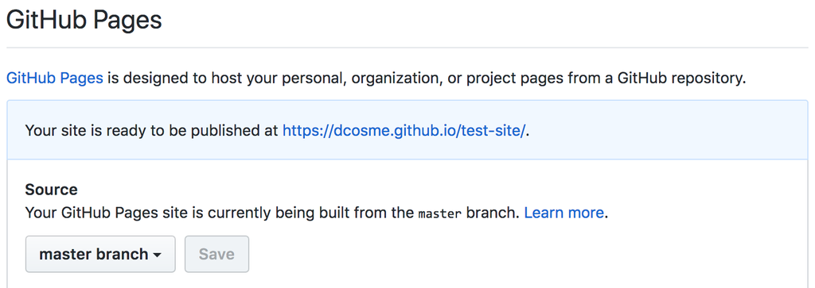

Go to your website and bask in the glory 🎉

# Workflow

Here is the [suggested workflow](https://slides.yihui.name/2017-rmarkdown-UNL-Yihui-Xie.html#30) from the main developer of **blogdown**, Yihui Xie:

> 1. Open your website project, click the “Serve Site” addin
> 2. Revise old pages/posts, or click the “New Post” addin
> 3. Write and save (take a look at the automatic preview)
> 4. Push everything to Github, or upload the public/ directory to Netlify directly

More on the recommended workflow [here](https://bookdown.org/yihui/blogdown/workflow.html).

# Mini (mega? ulimate?) hack

You final hack in this class if to create a personal website and post it to GitHub. You can use any template you want or make it from scratch using the **rmarkdown** package [(tutorial here)](http://nickstrayer.me/RMarkdown_Sites_tutorial/).

Here are the components you should include:

1. Homepage with a brief description about your research interests
2. A CV (either written in markdown or simply uploaded as a PDF)
3. A “Resources” tab with at least one of your ‘contributions to science’ from this class.

   Note: You decide how fancyyou want to be for #3. You may simply uploading your .html tutorial presentation. You can include the documentation and github link for the package you created last week. You can host a useful (or less useful) shiny app. You are limited only by your creativity (and your time).

Change colors, futz with custom CSS, make a shiny app and link to it – feel free to add anything else you’d like!

Go 🍌 🍌

Or just do the bare minimum because it’s the last week of the term 😄

# Helpful resources

- https://bookdown.org/yihui/blogdown/
- https://apreshill.github.io/data-vis-labs-2018/slides/06-slides_blogdown.html#1
- https://alison.rbind.io/slides/blogdown-workshop-slides
- https://alison.rbind.io/post/up-and-running-with-blogdown/#build-your-site-in-rstudio
- http://amber.rbind.io/blog/2016/12/19/creatingsite/
- https://gohugo.io/
- http://elipapa.github.io/markdown-cv/